# Comparison of blocking data for CMCC-CESM-RCP8.5, CMCC-CESM, JRA, MERRA, CFSR, ERA

2018-12-13

This is the results summary for DJF NP. Four of the datasets are reanalyses (ERA-Interim, CFSR, MERRA-2, JRA). Two are models: one is a historical dataset and one follows the RCP8.5 scenario.

All of the reanalysis is 6-hourly and all of the model data is daily (12Z). All data has been regridded to 1 degree in order to be able to do the spatial comparisons.

### Initial summary information

|  | CMCC-CESM-RCP8.5 | CMCC-CESM | JRA | MERRA | CFSR | ERA |
| --- | --- | --- | --- | --- | --- | --- |
| Number of years in dataset | 94 | 25 | 25 | 25 | 25 | 25 |
| Number of unique blobs | 408 | 141 | 127 | 119 | 126 | 126 |
| Number of merged blobs | 102 | 32 | 48 | 44 | 47 | 46 |
| Maximum blocking frequency | 0.2398 | 0.2462 | 0.2160 | 0.1918 | 0.1870 | 0.1991 |
| Interquartile range of blob centroid latitude | 40.82 53.81 | 37.11 53.81 | 36.25 51.88 | 36.75 52.00 | 37.00 52.00 | 36.00 51.50 |
| Number of blocked days | 5110 | 1539 | 1526 | 1468 | 1473 | 1531 |
| Average number of blocked days (divided by number of years) | 54.36 | 61.56 | 61.04 | 58.72 | 58.92 | 61.24 |
| Interquartile range of duration (days) | 6.00 16.00 | 6.00 15.00 | 7.12 15.25 | 7.25 15.50 | 7.06 14.44 | 7.25 14.94 |
| Interquartile range of speed (km/hr) | 2.92 11.58 | 2.78 11.55 | 2.13 12.90 | 2.89 13.43 | 3.97 15.37 | 2.88 13.17 |
| Interquartile range of blob size (10^6 km^2) | 35.26 93.59 | 30.82 82.97 | 31.91 78.90 | 32.38 78.63 | 31.97 78.02 | 32.12 78.92 |

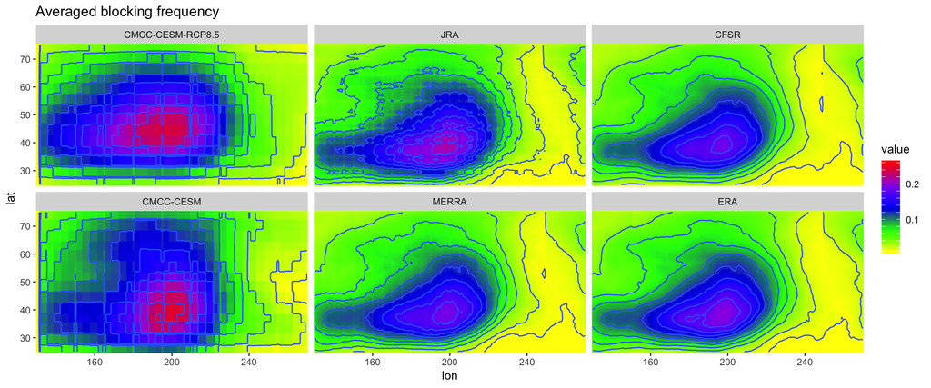

### Pearson Pattern Correlation

This chart shows the Pearson pattern correlation values between the average blocking patterns of the various models. The scale is from 0 to 1, but it should be noted that this metric will have a high correlation value even if the magnitudes of corresponding grid points differ.

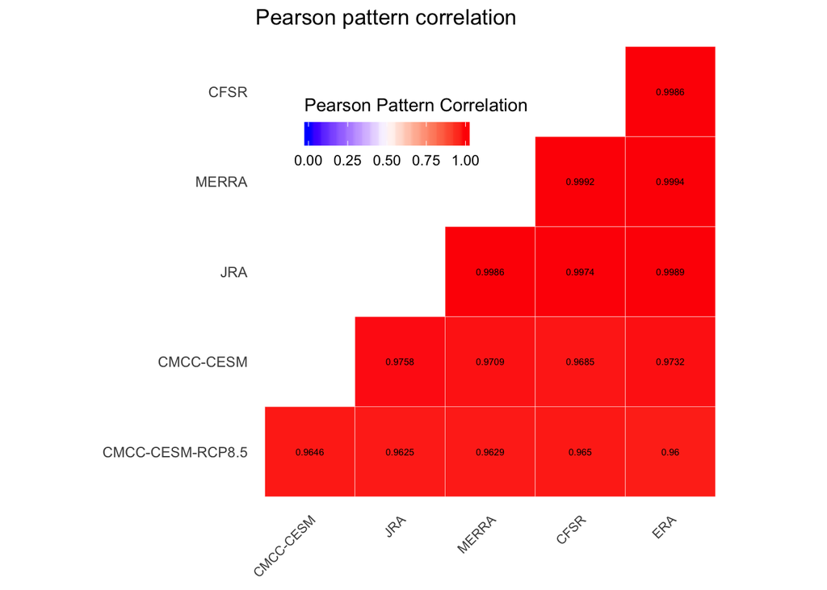